# Untitled1 slides

```python
import pandas as pd
import numpy as np
import seaborn as sns
from ast import literal_eval
import matplotlib.pyplot as plt
```

### Dataset

**keywords.csv** : Contains the movie plot keywords for our MovieLens movies. Available in the form of a stringified JSON Object.

**credits.csv**: Consists of Cast and Crew Information for all our movies. Available in the form of a stringified JSON Object.

**links.csv**: The file that contains the TMDB and IMDB IDs of all the movies featured in the Full MovieLens dataset.

**links_small.csv**: Contains the TMDB and IMDB IDs of a small subset of 9,000 movies of the Full Dataset.

**ratings_small.csv**: The subset of 100,000 ratings from 700 users on 9,000 movies.

The Full MovieLens Dataset consisting of 26 million ratings and 750,000 tag applications from 270,000 users on all the 45,000 movies in this dataset can be accessed [here](https://grouplens.org/datasets/movielens/latest/)

### Basic Analysis

```python
df = pd.read_csv("the-movies-dataset/movies_metadata.csv")
```

```python
df.shape
```

```
(45466, 24)
```

```python
df.info()
```

```
<class 'pandas.core.frame.DataFrame'>
RangeIndex: 45466 entries, 0 to 45465
Data columns (total 24 columns):
 #   Column                 Non-Null Count  Dtype
---  ------                 --------------  -----
 0   adult                  45466 non-null  object
 1   belongs_to_collection  4494 non-null   object
 2   budget                 45466 non-null  object
 3   genres                 45466 non-null  object
 4   homepage               7782 non-null   object
 5   id                     45466 non-null  object
 6   imdb_id                45449 non-null  object
 7   original_language      45455 non-null  object
 8   original_title         45466 non-null  object
 9   overview               44512 non-null  object
```

[output cut: 16 more lines]

```python
df.describe()
```

|  | revenue | runtime | vote_average | vote_count |
| --- | --- | --- | --- | --- |
| count | 4.546000e+04 | 45203.000000 | 45460.000000 | 45460.000000 |
| mean | 1.120935e+07 | 94.128199 | 5.618207 | 109.897338 |
| std | 6.433225e+07 | 38.407810 | 1.924216 | 491.310374 |
| min | 0.000000e+00 | 0.000000 | 0.000000 | 0.000000 |
| 25% | 0.000000e+00 | 85.000000 | 5.000000 | 3.000000 |
| 50% | 0.000000e+00 | 95.000000 | 6.000000 | 10.000000 |
| 75% | 0.000000e+00 | 107.000000 | 6.800000 | 34.000000 |
| max | 2.787965e+09 | 1256.000000 | 10.000000 | 14075.000000 |

```python
df["overview"].loc[0]
```

```
"Led by Woody, Andy's toys live happily in his room until Andy's birthday brings Buzz Lightyear onto the scene. Afraid of losing his place in Andy's heart, Woody plots against Buzz. But when circumstances separate Buzz and Woody from their owner, the duo eventually learns to put aside their differen…
```

```python
df1= df.copy()
```

#### What are the top 10 voted Movie ?

```python
df1.sort_values(by=["vote_average","vote_count"],ascending=False)[["original_title","vote_average"]].head(10)
```

|  | original_title | vote_average |
| --- | --- | --- |
| 32440 | Mariposa | 10.0 |
| 34296 | Mera Naam Joker | 10.0 |
| 35200 | Майдан | 10.0 |
| 36633 | Avetik | 10.0 |
| 42614 | Frankie Boyle: Hurt Like You've Never Been Loved | 10.0 |
| 3160 | Gendernauts: A Journey Through Shifting Identi... | 10.0 |
| 8926 | Common Threads: Stories from the Quilt | 10.0 |
| 21091 | Mababangong Bangungot | 10.0 |
| 21616 | Almost Kings | 10.0 |
| 26170 | Katt Williams: Priceless: Afterlife | 10.0 |

#### Does the movie spend more budget has more vote??

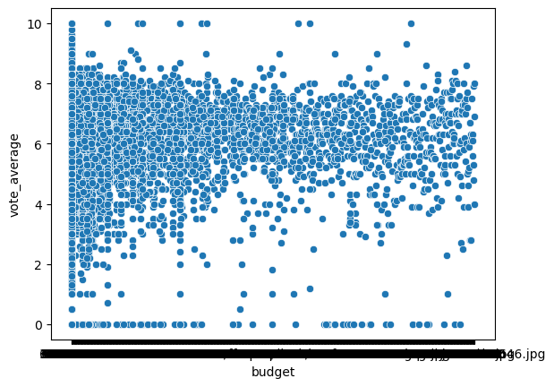

```python
sns.scatterplot(data=df1, x="budget", y="vote_average")
```

```python
df1["vote_count"] = df1["vote_count"].fillna(0)
# df1["vote_count"] = np.log(df1["vote_count"]).fillna(0)
```

```python
df1["vote+count"] = 0.5*df1["vote_average"].astype(float) + 0.01*df1["vote_count"]
```

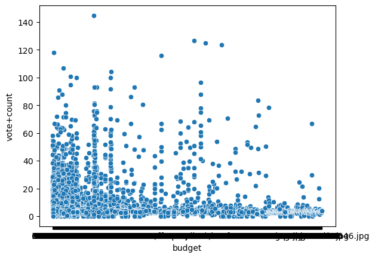

```python
sns.scatterplot(data=df1, x="budget", y="vote+count")
```

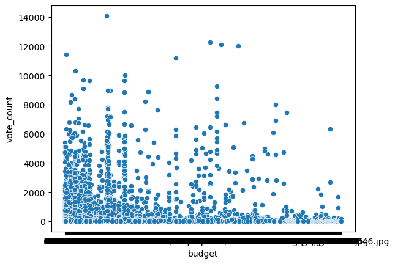

```python
sns.scatterplot(data=df1, x="budget", y="vote_count")
```

- some data in directionary form so we need to clean linke (genre , language .etc)

## Recommendation Engine

### Popularity

We use the TMDB Ratings to come up with our **Top Movies Chart.** I will use IMDB's *weighted rating* formula to construct my chart. Mathematically, it is represented as follows:

Weighted Rating (WR) = $(\frac{v}{v + m} . R) + (\frac{m}{v + m} . C)$

where,

- *v* is the number of votes for the movie
- *m* is the minimum votes required to be listed in the chart
- *R* is the average rating of the movie
- *C* is the mean vote across the whole report

```python
vote_counts = df[df['vote_count'].notnull()]['vote_count'].astype('int')
vote_averages = df[df['vote_average'].notnull()]['vote_average'].astype('int')
C = vote_averages.mean()
C
```

```
5.244896612406511
```

```python
# vote_counts.hist()
```

```python
# keep only movie that has average_vote more than the 95% quantile
m = vote_counts.quantile(0.95)
m #number of vote
```

```
434.0
```

```python
df['year'] = pd.to_datetime(df['release_date'], errors='coerce').apply(lambda x: str(x).split('-')[0] if x != np.nan else np.nan)
```

```python
qualified = df[(df['vote_count'] >= m) & (df['vote_count'].notnull()) & (df['vote_average'].notnull())][['title', 'year', 'vote_count', 'vote_average', 'popularity', 'genres']]
qualified['vote_count'] = qualified['vote_count'].astype('int')
qualified['vote_average'] = qualified['vote_average'].astype('int')
qualified.shape
```

```
(2274, 6)
```

```python
def weighted_rating(x):
    v = x['vote_count']
    R = x['vote_average']
    return (v/(v+m) * R) + (m/(m+v) * C)
```

```python
qualified['wr'] = qualified.apply(weighted_rating, axis=1)
```

```python
qualified = qualified.sort_values('wr', ascending=False).head(250)
```

#### Top10 Movie To Recommend Base On Popularity

```python
qualified.head(10)[["title","year"]]
```

|  | title | year |
| --- | --- | --- |
| 15480 | Inception | 2010 |
| 12481 | The Dark Knight | 2008 |
| 22879 | Interstellar | 2014 |
| 2843 | Fight Club | 1999 |
| 4863 | The Lord of the Rings: The Fellowship of the Ring | 2001 |
| 292 | Pulp Fiction | 1994 |
| 314 | The Shawshank Redemption | 1994 |
| 7000 | The Lord of the Rings: The Return of the King | 2003 |
| 351 | Forrest Gump | 1994 |
| 5814 | The Lord of the Rings: The Two Towers | 2002 |

[figure not shown]

Bro I Only Like Fantasy Movie .....

```python
df['genres'] = df['genres'].fillna('[]').apply(literal_eval).apply(lambda x: [i['name'] for i in x] if isinstance(x, list) else [])
```

```python
s = df.apply(lambda x: pd.Series(x['genres']),axis=1).stack().reset_index(level=1, drop=True)
s.name = 'genre'
gen_df = df.drop('genres', axis=1).join(s)
```

```python
def build_chart_g(genre, percentile=0.85):
    df = gen_df[gen_df['genre'] == genre]
    vote_counts = df[df['vote_count'].notnull()]['vote_count'].astype('int')
    vote_averages = df[df['vote_average'].notnull()]['vote_average'].astype('int')
    C = vote_averages.mean()
    m = vote_counts.quantile(percentile)

    qualified = df[(df['vote_count'] >= m) & (df['vote_count'].notnull()) & (df['vote_average'].notnull())][['title', 'year', 'vote_count', 'vote_average', 'popularity']]
    qualified['vote_count'] = qualified['vote_count'].astype('int')
    qualified['vote_average'] = qualified['vote_average'].astype('int')
    # print( qualified)
    qualified['wr'] =  (qualified['vote_count']/(qualified['vote_count']+m) * qualified['vote_average']) + (m/(m+qualified['vote_count']) * C)
    qualified = qualified.sort_values('wr', ascending=False).drop_duplicates(subset=["title"]).head(250)

    return qualified[["title","year"]]
```

##### Here you go bro ...

```python
build_chart_g("Fantasy").head(10)
```

|  | title | year |
| --- | --- | --- |
| 4863 | The Lord of the Rings: The Fellowship of the Ring | 2001 |
| 7000 | The Lord of the Rings: The Return of the King | 2003 |
| 5814 | The Lord of the Rings: The Two Towers | 2002 |
| 3030 | The Green Mile | 1999 |
| 5481 | Spirited Away | 2001 |
| 9698 | Howl's Moving Castle | 2004 |
| 2884 | Princess Mononoke | 1997 |
| 5833 | My Neighbor Totoro | 1988 |
| 926 | It's a Wonderful Life | 1946 |
| 14551 | Avatar | 2009 |

### Conten base

- we use small dataset instead of full dataset because of our computational resource

```python
from sklearn.feature_extraction.text import TfidfVectorizer
```

```python
links_small = pd.read_csv('the-movies-dataset/links_small.csv')
links_small = links_small[links_small['tmdbId'].notnull()]['tmdbId'].astype('int')
```

```python
links_small
```

```
0          862
1         8844
2        15602
3        31357
4        11862
         ...
9120    402672
9121    315011
9122    391698
9123    137608
9124    410803
Name: tmdbId, Length: 9112, dtype: int32
```

```python
# drop this because it didn't have imdb id
df = df.drop([19730, 29503, 35587])
```

```python
# df
```

```python
df['id'] = df['id'].astype('int')
```

```python
has_imdb = df[df['id'].isin(links_small)]
has_imdb.shape
```

```
(9099, 25)
```

```python
has_imdb['tagline'] = has_imdb['tagline'].fillna('')
has_imdb['description'] =has_imdb['overview'] + has_mdb['tagline']
has_imdb['description'] = has_imdb['description'].fillna('')
```

```python
tf = TfidfVectorizer(analyzer='word',ngram_range=(1, 2),min_df=0, stop_words='english')
tfidf_matrix = tf.fit_transform(has_imdb['description'])
```

[output not shown]

```python
has_imdb.columns
```

```
Index(['adult', 'belongs_to_collection', 'budget', 'genres', 'homepage', 'id',
       'imdb_id', 'original_language', 'original_title', 'overview',
       'popularity', 'poster_path', 'production_companies',
       'production_countries', 'release_date', 'revenue', 'runtime',
       'spoken_languages', 'status', 'tagline', 'title', 'video',
       'vote_average', 'vote_count', 'year'],
      dtype='object')
```